# A Variety of Visuals with `ggplot`

Rei Sanchez-Arias

## Set up

Before we jump into it, make sure that you have Rstudio, R and the package `tidyverse` installed.

```r
library(tidyverse)
```

[figure not shown]

## Data Visualization

We will learn how to visualize data using the `ggplot2` package: one of the most elegant and most versatile systems for creating graphs.

`ggplot2` implements the **grammar of graphics**, a coherent system for describing and building graphs.

The `ggplot2` package is part of the `tidyverse`

[figure not shown]

# `mtcars` and `economics` datasets

## Data

Our data set will be `mtcars`, a built-in dataset in `R` with Motor Trend Car Road Tests.

The data comprises **fuel consumption** and 10 aspects of automobile design and performance for 32 automobiles (1973 - 1974 models).

```r
# Check the dataset
head(mtcars)
```

```
##                    mpg cyl disp  hp drat    wt  qsec vs am gear carb
## Mazda RX4         21.0   6  160 110 3.90 2.620 16.46  0  1    4    4
## Mazda RX4 Wag     21.0   6  160 110 3.90 2.875 17.02  0  1    4    4
## Datsun 710        22.8   4  108  93 3.85 2.320 18.61  1  1    4    1
## Hornet 4 Drive    21.4   6  258 110 3.08 3.215 19.44  1  0    3    1
## Hornet Sportabout 18.7   8  360 175 3.15 3.440 17.02  0  0    3    2
## Valiant           18.1   6  225 105 2.76 3.460 20.22  1  0    3    1
```

## Basic Scatter Plot

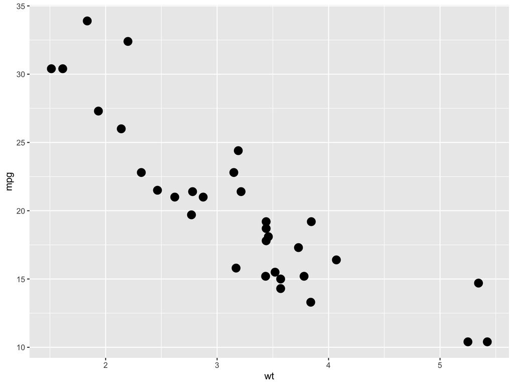

```r
p <- ggplot(mtcars)
p + geom_point(aes(wt, mpg), size=4)
```

## Scatterplot

You can add other variables if you wish:

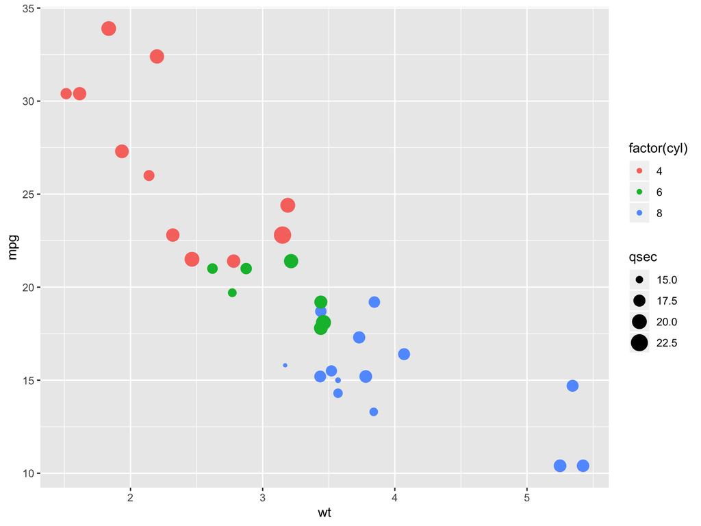

```r
# Add other variables
p + geom_point(aes(wt, mpg, colour=factor(cyl), size = qsec))
```

## Line Graph

For line graphs, the data points must be **grouped** so that it knows which points to connect.

Consider the artificial data frame below:

```r
dat1 <- data.frame(
    sex  = factor(c("Female","Female","Male","Male")),
    time = factor(c("Lunch","Dinner","Lunch","Dinner"),
                  levels = c("Lunch","Dinner")),
    total_bill = c(13.53, 16.81, 16.24, 17.42)
)
```

## Line Graph

A simple line graph is created by:

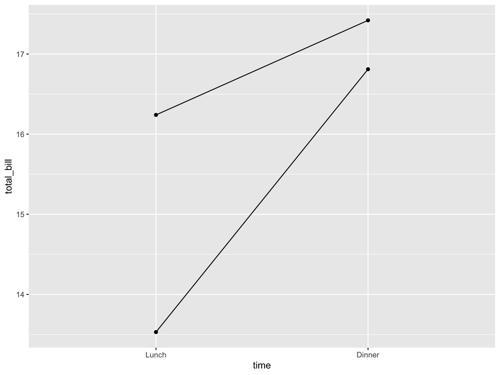

```r
p2 <- ggplot(data = dat1, aes(x=time, y=total_bill, group=sex))
p2 +  geom_point() +
  geom_line()
```

## Line Graph

Another example, using the data set `mtcars`:

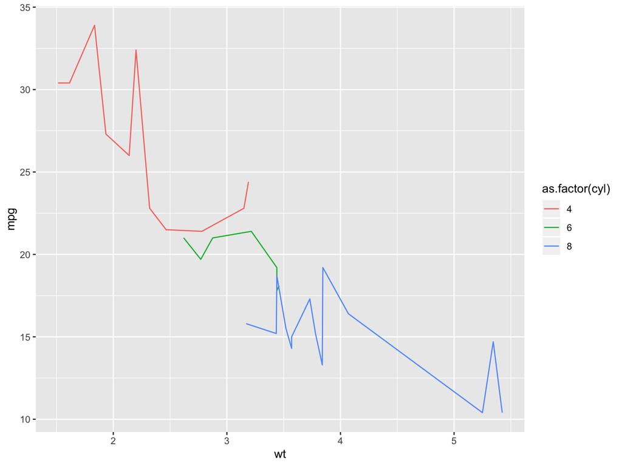

```r
p3 <- ggplot(mtcars) +
  geom_line(aes(x = wt, y = mpg, color = as.factor(cyl)))
p3
```

## Time Series

A time series can also be created in a simple way: let us use the built-in data set `economics`, that was produced from [US economic time series](http://research.stlouisfed.org/fred2).

| Variable | Description |
| --- | --- |
| `date` | Month of data collection |
| `psavert` | personal savings rate |
| `pce` | personal consumption expenditures, in billions of dollars |
| `unemploy` | number of unemployed in thousands |
| `unempmed` | median duration of unemployment, in weeks |
| `pop` | total population, in thousands |

## Time Series

This plot shows an unemployment rate over time.

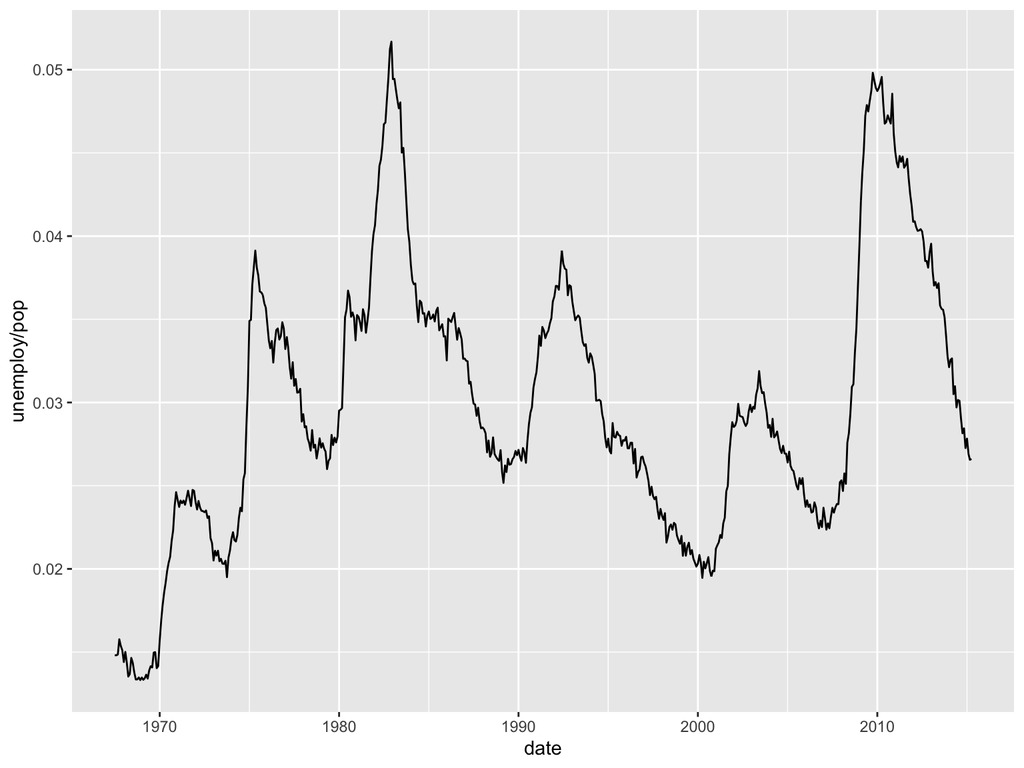

```r
p4 <- ggplot(economics, aes(date, unemploy / pop)) + geom_line()
p4
```

## Time Series

This second plot shows the median number of weeks unemployed.

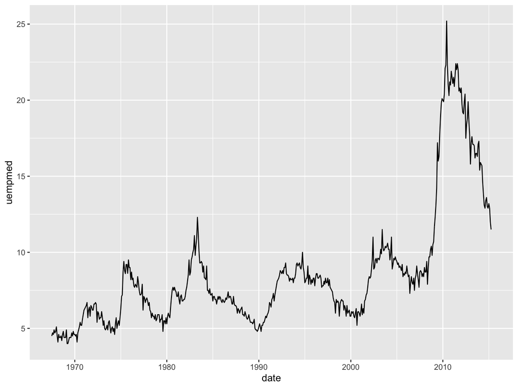

```r
p5 <- ggplot(economics, aes(date, uempmed)) + geom_line()
p5
```

# Bar Charts

## `mpg` dataset

We will use the `mpg` dataset. This dataset contains a subset of the fuel economy data that the [EPA](http://fueleconomy.gov) makes available. It contains only models which had a new release every year between 1999 and 2008 - this was used as a proxy for the popularity of the car.

There are a total of 234 rows and 11 variables, including `model` (model name), `year` (year of manufacture), `trans` (type of transmission), `hwy` (highway miles per gallon), among others.

## Using `geom_bar()`

By default, `geom_bar()` has the `stat` set to `count`. That means, when you provide just a continuous `x` variable (and no `y` variable), it tries to make a histogram out of the data.

In order to make a bar chart create bars instead of histogram, you need to do two things.

1. Set `stat = identity`
2. Provide both `x` and `y` inside `aes()` where, `x` is either character or factor and `y` is numeric.

## Stacked vertical bar chart

A bar chart can be drawn from a categorical column variable or from a separate frequency table.

```r
# prep frequency table
freqtable <- table(mpg$manufacturer)
df <- as.data.frame.table(freqtable)
head(df)
```

```
##        Var1 Freq
## 1      audi   18
## 2 chevrolet   19
## 3     dodge   37
## 4      ford   25
## 5     honda    9
## 6   hyundai   14
```

## Stacked bar chart (simple)

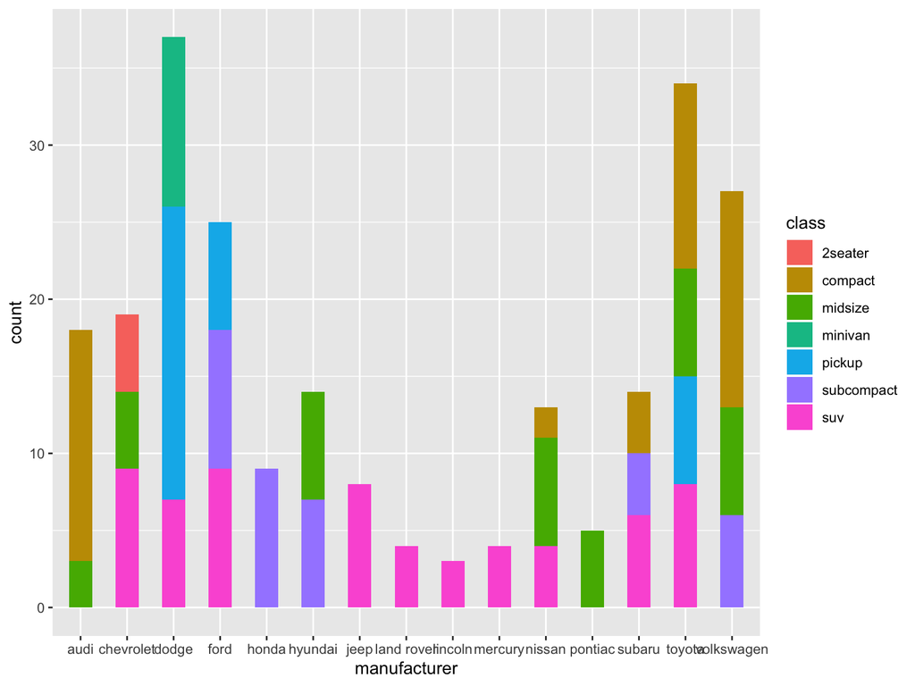

```r
# From on a categorical column variable
p6 <- ggplot(mpg, aes(manufacturer))
p6 + geom_bar(aes(fill=class), width = 0.5)
```

## Stacked bar chart (improved)

```r
# From on a categorical column variable
p7 <- ggplot(mpg, aes(manufacturer))
p7 + geom_bar(aes(fill=class), width = 0.5) +
  theme_classic() +
  theme(axis.text.x = element_text(angle = 65, vjust = 0.6)) +
  labs(title="Categorywise Bar Chart",
       subtitle="Manufacturer of vehicles",
       caption="Source: Manufacturers from 'mpg' dataset")
```

## Stacked bar chart (improved)

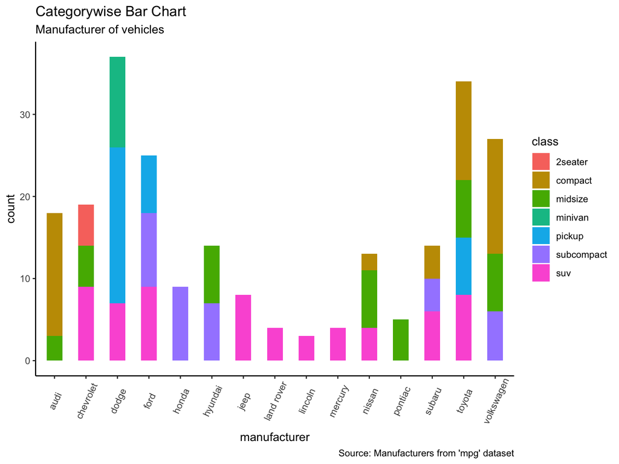

## Stacked horizontal bar chart

Simply do a **coordinate flip** in the previous graph:

```r
p8 <- ggplot(mpg, aes(manufacturer))
p8 + geom_bar(aes(fill=class), width = 0.5) +
  theme_classic() +
  labs(title="Categorywise Bar Chart",
       subtitle="Manufacturer of vehicles",
       caption="Source: Manufacturers from 'mpg' dataset") +
  coord_flip()
```

## Stacked horizontal bar chart

Simply do a **coordinate flip** in the previous graph:

[figure not shown]

# Extra

## Diverging bars

Diverging Bars is a bar chart that can handle both *negative and positive* values. This can be implemented by a smart tweak with `geom_bar()`.

In order to make sure you get diverging bars instead of just bars, make sure, your categorical variable has **2 categories** that changes values at a certain threshold of the continuous variable.

In our example, the `mpg` from the `mtcars` dataset is normalized by computing the z-score. Those vehicles with mpg above zero are marked green and those below are marked red.

## Diverging bars

```r
# Data Prep: load data
data("mtcars")
# create new column for car names
mtcars$`car name` <- rownames(mtcars)
# compute normalized mpg
mtcars$mpg_z <- round((mtcars$mpg - mean(mtcars$mpg))/sd(mtcars$mpg), 2)
# above / below avg flag
mtcars$mpg_type <- ifelse(mtcars$mpg_z < 0, "below", "above")
# sort
mtcars <- mtcars[order(mtcars$mpg_z), ]
# convert to factor to retain sorted order in plot
mtcars$`car name` <- factor(mtcars$`car name`, levels = mtcars$`car name`)
```

## Diverging bars

```r
# Diverging Barcharts
ggplot(mtcars, aes(x=`car name`, y = mpg_z, label = mpg_z)) +
  theme_bw() +
  geom_bar(stat='identity', aes(fill = mpg_type), width=.5)  +
  scale_fill_manual(name="Mileage",
                    labels = c("Above Average", "Below Average"),
                    values = c("above"="#00ba38", "below"="#f8766d")) +
  labs(subtitle = "Normalized mileage from 'mtcars'",
       title = "Diverging Bars") +
  coord_flip()
```

## Diverging bars

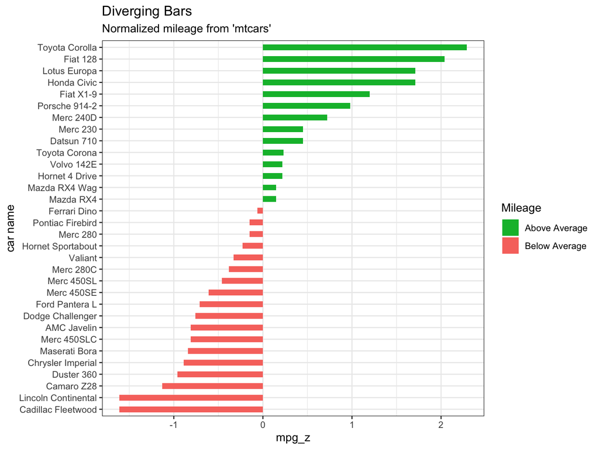